# Rena Repenning and Eddy Salazar

##### Parent reviews and needs

```
"Which of the following aspects would you like the We PLAY Center to address more often?

KEYS:
1. Stress Relief
2. Information about community resources
3. Information about how to foster my child’s development
4. Information about nurturing and responsive parenting strategies
5. Information about mouthing (biting, putting objects in their mouth)
6. Information about conflict resolution
7. Information about sharing
8. Information about nursing/ feeding
9. Information about temper tantrums
10. Information about sleeping
```

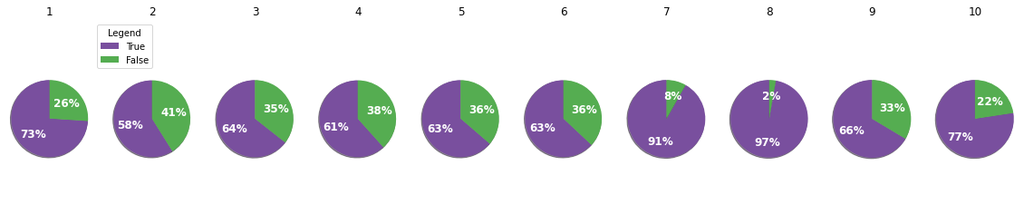

```python
desired_info = allIncoming[["Which of the following aspects would you like the We Play Center to address more often? Please select all that apply and use the space to write in any additional comments.","Unnamed: 109","Unnamed: 110","Unnamed: 111","Unnamed: 112","Unnamed: 113","Unnamed: 114","Unnamed: 115","Unnamed: 116","Unnamed: 117"]]
desired_info.columns = [["Stress Relief","Information about community resources","Information about how to foster my child’s development", "Information about nurturing and responsive parenting strategies","Information about mouthing (biting, putting objects in their mouth)","Information about conflict resolution","Information about sharing","Information about nursing/ feeding","Information about temper tantrums","Information about sleeping"]]
desired_info = ~desired_info.isna()
print('"Which of the following aspects would you like the We PLAY Center to address more often?\n')
plotPies(desired_info, ["True", "False"], True, False)
```

```
The We PLAY Center...
KEYS:
1. Provides an enriched learning environment, provides educational toys
2. Offers an adequate number of toys
3. Creates a positive welcoming friendly atmosphere
4. Staff is knowledgeable and answer questions willingly
5. Staff is patient and empathetic
```

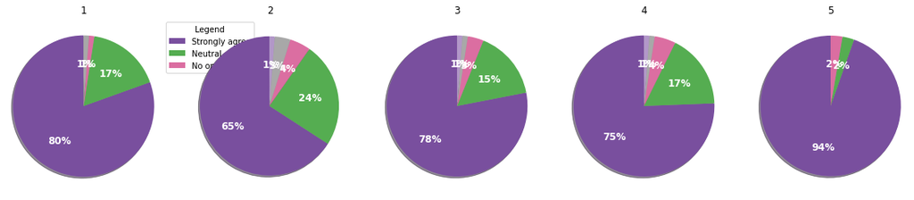

```
KEYS:
1. Been helpful to my family
2. Given me more confidence as a parent
3. Helped me to become a better parent
4. Provided me with positive parenting strategies
5. Supported me in my role as a parent/caregiver
6. Created a support system with other members of the We PLAY Center
```

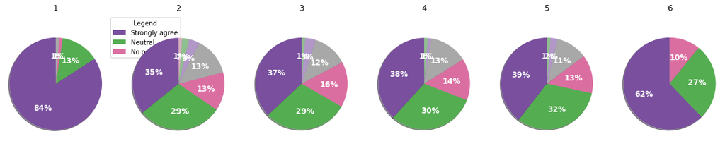

```python
other_WP_opinions = allIncoming[['"The We PLAY Center..."',"Unnamed: 86","Unnamed: 87","Unnamed: 88","Unnamed: 89",'"The We PLAY Center has..."',"Unnamed: 91","Unnamed: 92","Unnamed: 93","Unnamed: 94","Unnamed: 95"]]
other_WP_opinions.columns = [["Provides an enriched learning environment, provides educational toys","Offers an adequate number of toys","Creates a positive welcoming friendly atmosphere", "Staff is knowledgeable and answer questions willingly","Staff is patient and empathetic","Been helpful to my family","Given me more confidence as a parent","Helped me to become a better parent","Provided me with positive parenting strategies","Supported me in my role as a parent/caregiver","Created a support system with other members of the We PLAY Center"]]
print('The We PLAY Center...')
plotPies(other_WP_opinions.iloc[:, :5], ["Strongly agree", "Neutral", "No opinion"], True, False)
plotPies(other_WP_opinions.iloc[:, 5:], ["Strongly agree", "Neutral", "No opinion"], True, False)
```

### More Family Survey Questions

##### The We PLAY Center strives to create a welcoming environment with toys and caring, knowledgable staff. How well do parents think We PLAY meets these goals?

```
KEYS:
1. Provides an enriched learning environment
2. Provides educational toys
3. Offers an adequate number of toys
4. Creates a positive, welcoming, friendly atmosphere
5. Staff is knowledgeable and answer questions willingly
6. Staff is patient and empathetic
```

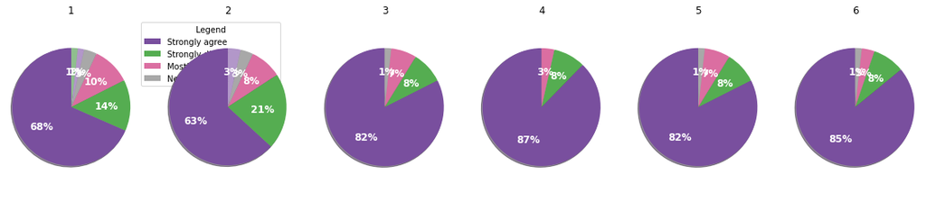

```python
environmentstatements_FD = familySurveyDf.iloc[1:, 42:48]
labels = ['Strongly agree','Strongly disagree', 'Mostly agree',
       'Neither disagree nor agree', 'Somewhat agree',
       'Somewhat disagree']
environmentstatements_FD.columns = familySurveyDf.iloc[0, 42:48]
plotPies(environmentstatements_FD, labels, True, False)
```

##### We PLAY strives to help parents and children grow. The questions below help to illustrate how well We PLAY is fulfilling those goals:

```
KEYS:
1. Do you feel supported in your role as a parent?
2. Do you feel confident in your role as a parent?
3. Do you feel you have a better understanding about age appropriate developmental milestones ?
4. Do you have a stronger bond with their child?
5. Has your child exhibited an increase in age-appropriate social skills?
```

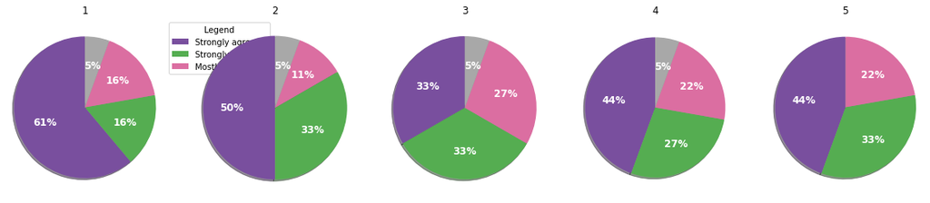

```python
attendance_feedback = familySurveyDf.iloc[1:, 48:53]
labels = ['Strongly agree','Strongly disagree', 'Mostly agree',
       'Neither disagree nor agree', 'Somewhat agree',
       'Somewhat disagree']
attendance_feedback.columns = familySurveyDf.iloc[0, 48:53]
plotPies(attendance_feedback, labels, True, False)
```

# Open Response

#### What will keep people coming back?

### Family Survey

```python
weplay_review = familySurveyDf.iloc[1:, 56:58]
labels = getLabels(weplay_review)
print("What will keep you coming back to the We PLAY Center?:\n")
print(labels[0][1:])
```

```
What will keep you coming back to the We PLAY Center?:

['The positive staff and positive environment.'
 'My kids love it there an I enjoy playing with my babies '
 'Friendly staff, fun space ' 'The activities and Social time for kids. '
 'The people' 'The staff!' 'The dedicated playspace for infants. '
 'Convenient location, clean, diverse set of families.'
 'Baby cafe is great.. really nice parents there too & staff. I like the diversity a lot too'
 'The stimulating activities and toys that I can’t provide. The socialization of having to cooperate with other kids her age. The diversity in children and parents who come'
 'Thursday' 'The interaction with other babies We Play provides '
 'Nice place to meet up with other moms. Only working part time  right now so its nice to find free activities. '
 'Clean, open, temperate space for babies to safely play and engage and explore and welcoming, helpful staff'
 'People and toys ' 'Increased open hours'
 'Free and indoor and enough space to play (not too crowded) '
 'Wonderful staff & encouraged & excited for us to have a diverse place to play!'
 'I really liked the friendly and helpful staff, the toys my children had access to, the separate baby area, and the relaxed attitudes of the other parents.'
 'Access to a beautiful, inclusive family space with friendly staff.'
 'The family aspect '
 'Community and engagement with other kids my child’s age'
 'Socialization and bright atmosphere and wonderful moms'
 'The amazing staff and the engaging activities.'
 'The positive atmosphere that encourages good play time with my child.'
 'Everything! The staff, the toys, the environment. It’s all great!'
 'Doing the same thing they been doin and that’s being nice.'
 'It was my first time there and the staff was so welcoming and positive that this will be our new go to. It was also very organized and clean. What a great place to go when the weather gets too humid to go outside. '
 'Yes  ' 'If my schedule stays the same. '
 'The staff, and the people there'
 'close to my house, free, friendly, opportunity to meet other moms and babies, lovely staff, opportunity for my baby to play with different things and other children '
 'For my child to acquire social skills '
 'Positive reinforcement explanation '
 'Chance for my kids to interact with others and a chance for me to hang out with other parents'
 'The children ' 'The environment '
 'Being able to enjoy activities with my son '
 'The instructions on how to properly deal with my kids'
 'Friendly staff and friendly parents, bright airy space & great toys'
 'The atmosphere ' 'Playing with my baby'
 'The space for 0-3 is great. I value the diversity of parents / caregivers  racially and economically. '
 'Love coming as is, would come more if there were additional hours it was open.'
 'The atmosphere it creates for my daughter'
 'Location, staff, other children'
 'We plan to attend regularly so our baby can socialize with other children in a safe and enriching environment.  '
 'Tye environment is warm and welcoming! Melanie and Christine remember every child’s name❤️. They are so helpful and encouraging.. patient with the kids.'
 'The opportunity for my child to engage with other children, opportunity to have a change of environment for myself and my son, opportunity to engage with other parents and professionals who understand child development ']
```

```python
print("What aspect of the We PLAY Center do you find most helpful?:\n")
print(labels[1][1:])
```

```
What aspect of the We PLAY Center do you find most helpful?:

['Different stuff'
 'Interactive space outside the house that is still indoors'
 'Safe area to play ' 'Other parents ' 'The staff!'
 'Dedicated playspace for infants with developmentally appropriate toys.'
 'Free!' 'The staff'
 'The staff was very friendly and made me feel very welcome!'
 'Being able to engage with other parents. Providing my baby with the opportunity to play with other children. Knowing that the staff is knowledgeable and helpful '
 'being around other adults in a social environment '
 'I’ve only been once but will see'
 'Other babies, parents and staff to interact with'
 'Various types of engagement for the children' 'Free and indoor' 'Staff'
 'Staff members and the song and snack at the end - that really helped transition my toddler for the time to leave.'
 'Baby cafe, toddler activities, baby gate on soft area, lovely staff. '
 'Everything' 'It is free!' 'The women on staff'
 'The kids are engaged and having fun '
 'The dedicated time and space to really focus on engaging in play with my baby without the distractions at home.'
 'That it’s a free space for my child to play with lots of learning experiences offered. '
 'The engagement of other kids'
 'The set up is very organized and there are duplicates of most toys which is helpful with toddlers. '
 "Being around mom's    " 'The separation of the age groups '
 'cost and availability '
 'The staff are knowledgeable in everything about kids'
 'They walk your through redirecting '
 'Easy space to watch my son while holding my newborn' 'Free play '
 'Comfort' 'Age appropriate activities for children '
 'The social engagement amongst the children' 'Everything '
 'Location, toys, staff, talking to other parents '
 'Different activities for little to learn ' 'The mothers '
 'Location , clean age appropriate play space. Staff modeling best practices for caregivers '
 'That it is staffed with educators that are very knowledgeable in interacting and working with young children.'
 'The information the staff gives about toddlers and their behavior'
 'Ease of access'
 "It's open more than one day, so that's easier for us to fit in our schedule. "
 'All of it! '
 'The ability to allow my child to engage in play with other kids in a safe space']
```

## Incoming Parent Reflection

### WordCloud

Open response to *What will keep you coming back to the We PLAY Center?* from incoming family surveys.

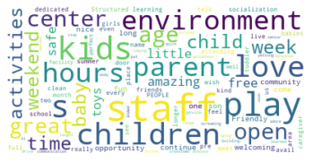

```python
!pip3 install wordcloud
from os import path
from PIL import Image
from wordcloud import WordCloud, STOPWORDS, ImageColorGenerator
# isolating column for word cloud:
text = allIncoming["What will keep you coming back to the We PLAY Center?"]
text = text.dropna()
#making df into a string for the wordcloud function
text = " ".join(response for response in text)
#filtering out uninformative words
omit = ['will', 'Yes', 'able', 'thing', 'old', 'bring', 'around', 'Maybe', 'though', 'Every', 'visit', 'now', 'days', 'year']
for w in omit:
    text = text.replace(w, '')
# Create and generate a word cloud image:
wordcloud = WordCloud(max_font_size=50, max_words=100, background_color="white").generate(text)
# Display the generated image:
plt.imshow(wordcloud, interpolation='bilinear')
plt.axis("off")
plt.show()
```

# Automatic updating for Git Pages

We use `https://github.com/renarepenning/weplaynoladata`'s gh-pages branch to display on [Rena's personal website](https://www.renarepenning.com)

```python
# update local branch
!git pull
# convert this file to HTML
!jupyter nbconvert --to html FinalTutorial.ipynb
# Delete old index.html
!rm index.html
# move MilestoneTwo.html into index.html
!mv FinalTutorial.html index.html

# Push to Rena's repo
!git config --global user.name "renarepenning"
!git config --global user.email "rrepenning@tulane.edu"
!git add -A
!git commit -m "auto update index.html"

# MUST PUSH MANUALLY
```

```
remote: Enumerating objects: 2, done.
remote: Counting objects: 100% (2/2), done.
remote: Compressing objects: 100% (2/2), done.
remote: Total 2 (delta 0), reused 0 (delta 0), pack-reused 0
Unpacking objects: 100% (2/2), 1.22 KiB | 32.00 KiB/s, done.
From https://github.com/renarepenning/weplaynoladata
   25002a2..82e3e5e  gh-pages   -> origin/gh-pages
Already up to date.
[NbConvertApp] Converting notebook FinalTutorial.ipynb to html
[NbConvertApp] Writing 2961869 bytes to FinalTutorial.html
[main 6b900f8] auto update index.html
 2 files changed, 417 insertions(+), 311 deletions(-)
```

#### Create a pull to merge `main` into `gh-pages`